# 第四次作业

## 1. EM算法理论练习

#### 1.1 推导三硬币模型的EM算法中隐变量后验分布的计算公式以及参数更新公式

**三硬币模型：**

假设有三枚硬币，分别记为A、B、C，这些硬币正面向上的概率分别是$ \pi , p , q $。

进行如下掷硬币试验：先掷硬币 A ，根据其结果选择硬币 B 或硬币 C ，正面选硬币 B ，反面选硬币 C ；然后掷选出的硬币，出现正面记为1，出现反面记为0；独立地重复 n 次试验。

假设只能观测到掷硬币的结果，不能观测到掷硬币的过程。问如何估计三硬币正面出现的概率，即三硬币模型的参数 $\theta = ( \pi , p , q )$。

**模型构建：**

引入随机变量 $ x \in\{0,1\}$ 表示一次试验观测的结果是 1 或者 0 ， $x$ 是观测变量，可以观测。

引入随机变量 $z\in\{0,1\}$ 表示未观测到的掷硬币 A 的结果，$z$ 是隐变量，不可观测。其中$z=1$表示硬币A为正面，$z=0$表示硬币A为反面。

写出似然函数的对数$LL(\theta)$，并引入隐变量： $$ \begin{aligned} LL(\theta)&= \sum_{i=1}^{n}log\left(P ( x_i \mid \theta)\right)\\ &=\sum_{i=1}^{n}log\left(P ( x_i,z_i=1 \mid \theta)+P ( x_i,z_i=0 \mid \theta)\right)\\ &=\sum_{i=1}^{n}log\left(Q(z_i=1)\frac{P ( x_i,z_i=1 \mid \theta)}{Q(z_i=1)}+Q(z_i=0)\frac{P ( x_i,z_i=0 \mid \theta)}{Q(z_i=0)}\right)\\ &\geq\sum_{i=1}^{n}\left[Q(z_i=1) log\left(\frac{P ( x_i,z_i=1 \mid \theta)}{Q(z_i=1)}\right)+Q(z_i=0) log\left(\frac{P ( x_i,z_i=0 \mid \theta)}{Q(z_i=0)}\right)\right]\\ \end{aligned} $$

**E（expectation）步：**

由EM算法知，隐变量的后验分布计算公式为： $$ \begin{aligned} Q(z_i=1)&= P(z_i=1 \mid x_i,\theta^{(t)})\\ &= \frac{P(z_i=1 \mid \theta^{(t)})P ( x_i \mid z_i = 1,\theta^{(t)})}{\sum_{z_i=0}^{z_i=1}P(z_i\mid \theta^{(t)})P ( x_i \mid z_i,\theta^{(t)})}\\ &=\frac{\pi^{(t)} [p^{(t)}]^{x_i} [1-p^{(t)}]^{1-x_i}}{\pi^{(t)} [p^{(t)}]^{x_i} [1-p^{(t)}]^{1-x_i}+[1-\pi^{(t)}] [q^{(t)}]^{x_i} [1-q^{(t)}]^{1-x_i}}\\ &\triangleq \mu_i^{(t)}\\ Q(z_i=0)&= P(z_i=0 \mid x_i,\theta^{(t)})\\ &= \frac{P(z_i=0 \mid \theta^{(t)})P ( x_i \mid z_i = 0,\theta^{(t)})}{\sum_{z_i=0}^{z_i=1}P(z_i\mid \theta^{(t)})P ( x_i \mid z_i,\theta^{(t)})}\\ &= 1-\mu_i^{(t)} \end{aligned} $$

**M（maximize）步：**

由于$Q^{(t)}(z)logQ^{(t)}(z)$是常数，所以参数 $\theta$ 更新公式为： $$ \begin{aligned} \theta^{(t+1)} &= \mathop{\arg\max}\limits_{\theta} \sum_{i=1}^{n}\left[Q(z_i=1) log\left(\frac{P ( x_i,z_i=1 \mid \theta)}{Q(z_i=1)}\right)+Q(z_i=0) log\left(\frac{P ( x_i,z_i=0 \mid \theta)}{Q(z_i=0)}\right)\right]\\ &=\mathop{\arg\max}\limits_{\theta} \sum_{i=1}^{n} \sum_{z_i} Q(z_i) log\left(P ( x_i,z_i \mid \theta)\right)\\ &=\mathop{\arg\max}\limits_{\theta} \sum_{i=1}^{n}\left[\mu_i^{(t)}log(\pi p^{x_i}(1-p)^{1-x_i})+(1-\mu_i^{(t)})log((1-\pi) q^{x_i}(1-q)^{1-x_i}) \right]\\ &=\mathop{\arg\max}\limits_{\theta} \sum_{i=1}^{n}\left\{\mu_i^{(t)}\left[log(\pi)+{x_i}log(p)+(1-x_i)log(1-p)\right]+(1-\mu_i^{(t)})\left[log(1-\pi)+x_i log(q)+(1-x_i)log(1-q)\right] \right\}\\ &\triangleq\mathop{\arg\max}\limits_{\pi,p,q} f(\pi,p,q) \end{aligned} $$

将f(x)分别对$\theta = ( \pi , p , q )$求偏导，当$\sum_{i=1}^{n}\mu_i^{(t)} \neq 0$且$\sum_{i=1}^{n}(1-\mu_i^{(t)}) \neq 0$时： $$ \left\{ \begin{aligned} \frac{\partial f(\pi , p , q)}{\partial \pi} &= \sum_{i=1}^{n}\left(\frac{\mu_i^{(t)}}{\pi}-\frac{1-\mu_i^{(t)}}{1-\pi}\right) \equiv 0 &\Longrightarrow \pi (\sum_{i=1}^{n}(\mu_i^{(t)}-1)) &= (\pi - 1)(\sum_{i=1}^{n}\mu_i^{(t)}) &\Longrightarrow \pi &= \frac{1}{n}\sum_{i=1}^{n}\mu_i^{(t)}\\ \frac{\partial f(\pi , p , q)}{\partial p} &=\sum_{i=1}^{n}\left(\mu_i^{(t)}\frac{x_i}{p}-\mu_i^{(t)}\frac{x_i-1}{p-1}\right) \equiv 0 &\Longrightarrow (p-1)\sum_{i=1}^{n}x_i\mu_i^{(t)} &= p\sum_{i=1}^{n}(x_i-1)\mu_i^{(t)} &\Longrightarrow p &= \frac{\sum_{i=1}^{n}x_i\mu_i^{(t)}}{\sum_{i=1}^{n}\mu_i^{(t)}}\\ \frac{\partial f(\pi , p , q)}{\partial q} &=\sum_{i=1}^{n}\left((1-\mu_i^{(t)})\frac{x_i}{q}-(1-\mu_i^{(t)})\frac{x_i-1}{q-1}\right) \equiv 0 &\Longrightarrow (q-1)\sum_{i=1}^{n}x_i(1-\mu_i^{(t)}) &= q\sum_{i=1}^{n}(x_i-1)(1-\mu_i^{(t)}) &\Longrightarrow q &= \frac{\sum_{i=1}^{n}x_i(1-\mu_i^{(t)})}{\sum_{i=1}^{n}(1-\mu_i^{(t)})}\\ \end{aligned} \right. $$ 当$\sum_{i=1}^{n}\mu_i^{(t)} = 0$ 时，即$\pi = 0$ 时，参数 $p$ 的取值对结论无影响

当$\sum_{i=1}^{n}(1-\mu_i^{(t)})= 0$ 时，即$\pi = 1$ 时，参数 $q$ 的取值对结论无影响

#### 1.2 假设硬币A、B、C正面向上的概率分别是0.7、0.3、0.6，按照三硬币模型的数据生成过程独立地重复100次试验并记录观测结果的序列

```python
import numpy as np
def three_coins_model(pi,p,q): #分别为ABC硬币正面向上概率
    z = np.random.choice([0,1],p=[1-pi,pi]) #投硬币A，其中z=1表示正面，z=0表示反面
    if z == 1:
        x = np.random.choice([0,1],p=[1-p,p]) #投硬币B，其中x=1表示正面，x=0表示反面
    elif z == 0:
        x = np.random.choice([0,1],p=[1-q,q]) #投硬币C，其中x=1表示正面，x=0表示反面
    else:
        return "error: something went wrong with z"
    return x
x_list = []
for i in range(0,100):
    x_list.append(three_coins_model(0.7,0.3,0.6))
print("100次独立重复试验结果：\n",x_list)
```

```
100次独立重复试验结果：
 [0, 1, 0, 0, 0, 0, 0, 0, 0, 0, 0, 0, 1, 0, 0, 0, 0, 1, 0, 1, 1, 0, 1, 0, 1, 1, 0, 0, 0, 0, 1, 1, 1, 0, 0, 0, 0, 1, 0, 0, 0, 0, 0, 0, 0, 0, 0, 1, 0, 1, 1, 1, 0, 0, 0, 0, 0, 0, 0, 1, 1, 1, 0, 0, 0, 0, 0, 1, 1, 1, 0, 1, 0, 0, 0, 0, 0, 0, 0, 1, 0, 0, 1, 1, 0, 0, 1, 0, 1, 1, 0, 0, 1, 0, 0, 1, 1, 0, 1, 1…
```

#### 1.3 利用EM算法根据上述观测序列估计各硬币正面向上的概率

```
0.37791574858448046 0.741185877323549 0.09627985951218022 -64.10354778811555
0.8794275954353623 0.2739006813969091 0.8221133411822208 -64.10354778811556
0.5186876268611077 0.23051970499195382 0.45798174652242046 -64.10354778811556
0.533677915017902 0.03893590769298998 0.6845499628766888 -64.10354778811558
0.3676406814907094 0.09656613275127825 0.48152743580060614 -64.10354778811555
0.8785501870434601 0.26983609645585255 0.8475554180101406 -64.10354778811556
0.1395277206185737 0.07204563246756793 0.3834494672605473 -64.10354778811556
0.6373205893289423 0.48732703584085674 0.08110867464891316 -64.10354778811556
0.07238132728958667 0.6375894792064936 0.3167793360288392 -64.10354778811555
0.8988653112771975 0.3274905536772214 0.4511815095772829 -64.10354778811555
EM算法估计的各硬币正面向上的概率分别是： (0.8988653112771975, 0.3274905536772214, 0.4511815095772829)
```

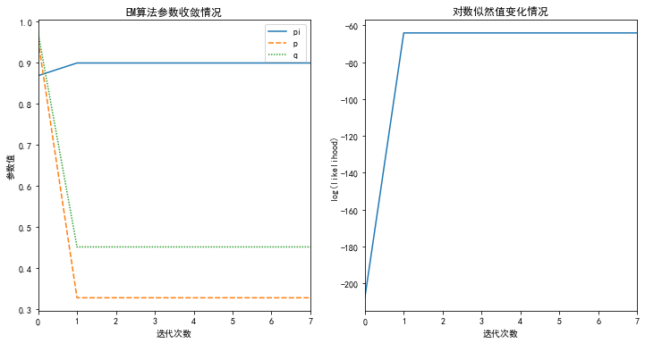

```python
import matplotlib.pyplot as plt
import pandas as pd
import seaborn as sns
import numpy as np
plt.rcParams['font.sans-serif'] = ['SimHei']  # 显示汉字
plt.rcParams['axes.unicode_minus']=False


def get_loglikelihood(theta_list, x): #获得指定参数下似然函数值
    [pi, p, q] = theta_list
    x = np.array(x)
    likelihood = (pi*(p**x)*((1-p)**(1-x)))+((1-pi)*(q**x)*((1-q)**(1-x)))
    loglikelihood = np.log(likelihood).sum()
    # for x_i in x:
    #     loglikelihood += np.log(pi*(p**x_i)*((1-p)**(1-x_i))+(1-pi)*(q**x_i)*((1-q)**(1-x_i)))
    return loglikelihood


# x表示结果序列; t表示循环迭代次数;initial_theta_list表示起始参数,初始值都为0.5
def EM_algorithm(x, t, initial_theta_list=[0.5, 0.5, 0.5]):
    [pi, p, q] = initial_theta_list
    loglikelihood = get_loglikelihood([pi, p, q], x)
    result_list = [[pi, p, q, loglikelihood]]
    for i in range(t):
        mu = []
        for x_i in x:
            mu.append((pi*p**x_i*(1-p)**(1-x_i))/(pi*(p**x_i) *
                      ((1-p)**(1-x_i))+(1-pi)*(q**x_i)*((1-q)**(1-x_i))))
        pi = sum(mu)/len(mu)
        p = sum([mu[i]*x[i] for i in range(len(x))]) / sum(mu)
        q = sum([(1-mu[i])*x[i] for i in range(len(x))]) / \
            sum([1-mu[i] for i in range(len(mu))])
        loglikelihood = get_loglikelihood([pi, p, q], x)
        result_list.append([pi, p, q, loglikelihood])
        if result_list[i+1] == result_list[i]:
            break
    return result_list, pi, p, q, loglikelihood


def draw_plot(result_list):
    data = pd.DataFrame(result_list, columns=["pi", "p", "q", "loglikelihood"])
    fig = plt.figure(figsize=(12, 6))
    ax1=fig.add_subplot(121)
    plt.title('EM算法参数收敛情况')
    plt.xlabel('迭代次数')
    plt.ylabel('参数值')
    plt.margins(x=0)
    sns.lineplot(data=data.iloc[:,0:3])
    ax2=fig.add_subplot(122)
    plt.title('对数似然值变化情况')
    plt.xlabel('迭代次数')
    plt.ylabel('log(likelihood)')
    plt.margins(x=0)
    sns.lineplot(data=data["loglikelihood"])
    plt.savefig("pic.png", dpi=300)


for i in range(10):
    initial_theta_list = np.random.rand(3)
    result_list, pi, p, q, loglikelihood = EM_algorithm(
        x_list, 100, initial_theta_list=initial_theta_list)
    print(pi, p, q, loglikelihood)
print("EM算法估计的各硬币正面向上的概率分别是：", (pi, p, q))
draw_plot(result_list)
```

## 2. 推导高斯混合模型的EM算法

**多元高斯（正态）分布** $$ P(\boldsymbol{x} \mid \boldsymbol{\Sigma},\boldsymbol{\mu})=\frac{1}{(2 \pi)^{\frac{m}{2}}|\boldsymbol{\Sigma}|^{\frac{1}{2}}} \exp \left\{-\frac{1}{2}(\boldsymbol{x}-\boldsymbol{\mu})^{\top} \boldsymbol{\Sigma}^{-1}(\boldsymbol{x}-\boldsymbol{\mu})\right\} $$ 其中 $x$ 是 $m$ 维随机变量, $\mu$ 是 $m$ 维均值向量, $\Sigma$ 是 $m \times m$ 的协方差矩阵

**高斯混合模型对数似然函数**

高斯混合模型是由一系列高斯分布按照参数$\alpha_k$组成的混合模型，其中$\alpha_k \geq 0$且$\sum_{k=1}^K \alpha_k =1$。

观测数据 $X=\left\{\boldsymbol{x}_{1}, \ldots, \boldsymbol{x}_{n}\right\}$ 的似然函数为： $$ \begin{aligned} L(\theta) &=P(X)=\prod_{i=1}^{n} P\left(\boldsymbol{x}_{i}\right) \\ &=\prod_{i=1}^{n}\left(\sum_{z_{i} \in\{1, \ldots, K\}} P\left(\boldsymbol{x}_{i}, z_{i}\right)\right) \\ &=\prod_{i=1}^{n}\left(\sum_{z_{i} \in\{1, \ldots, K\}} P\left(\boldsymbol{x}_{i} \mid z_{i}\right) P\left(z_{i}\right)\right) \\ &=\prod_{i=1}^{n}\left(\sum_{k=1}^{K} \alpha_{k} P\left(\boldsymbol{x}_{i} \mid \boldsymbol{\mu}_{k}, \boldsymbol{\Sigma}_{k}\right)\right) \end{aligned} $$ 对数似然函数为 $$ L L(\theta)=\sum_{i=1}^{n} \log \left(\sum_{k=1}^{K} \alpha_{k} P\left(\boldsymbol{x}_{i} \mid \boldsymbol{\mu}_{k}, \boldsymbol{\Sigma}_{k}\right)\right) $$

**M(maximize)步：**

参数$\theta = (\alpha,\boldsymbol{\mu}, \boldsymbol{\Sigma})$的更新公式为： $$ \begin{aligned} \theta^{*}&=\underset{\theta}{\arg \max } \sum_{i=1}^{n} \sum_{k=1}^{K} \gamma_{i k} \log \left(P\left(\boldsymbol{x}_{i} \mid z_{i}=k, \theta\right) P\left(z_{i}=k \mid \theta\right)\right) \\ &=\underset{\theta}{\arg \max } \sum_{i=1}^{n} \sum_{k=1}^{K} \gamma_{i k}\left\{\log P\left(\boldsymbol{x}_{i} \mid \boldsymbol{\mu}_{k}, \boldsymbol{\Sigma}_{k}\right)+\log \alpha_{k}\right\} \\ &=\underset{\alpha_{k},\boldsymbol{\mu}_{k}, \boldsymbol{\Sigma}_{k}}{\arg \max } \sum_{i=1}^{n} \sum_{k=1}^{K} \gamma_{i k}\left\{\log \left\{\frac{1}{(2 \pi)^{\frac{n}{2}}\left|\boldsymbol{\Sigma}_{k}\right|^{\frac{1}{2}}} \exp \left\{-\frac{1}{2}\left(\boldsymbol{x}_{i}-\boldsymbol{\mu}_{k}\right)^{\top} \boldsymbol{\Sigma}_{k}^{-1}\left(\boldsymbol{x}_{i}-\boldsymbol{\mu}_{k}\right)\right\}\right\}+\log \alpha_{k}\right\} \\ &=\underset{\alpha_{k},\boldsymbol{\mu}_{k}, \boldsymbol{\Sigma}_{k}}{\arg \min } \sum_{i=1}^{n} \sum_{k=1}^{K} \gamma_{i k}\left\{\frac{1}{2} \log \left|\boldsymbol{\Sigma}_{k}\right|+\frac{1}{2}\left(\boldsymbol{x}_{i}-\boldsymbol{\mu}_{k}\right)^{\top} \boldsymbol{\Sigma}_{k}^{-1}\left(\boldsymbol{x}_{i}-\boldsymbol{\mu}_{k}\right)-\log \alpha_{k}\right\}\\ &\triangleq\mathop{\arg\min}\limits_{\theta} f(\alpha,\boldsymbol{\mu}, \boldsymbol{\Sigma}) \end{aligned} $$

将$f(\cdot)$分别对$\boldsymbol{\mu}, \boldsymbol{\Sigma}$求偏导，当$\sum_{i=1}^{n}\gamma_{ik}^{(t)} \neq 0$对所有$k = {1,2,\cdots,K}$成立时： $$ \left\{ \begin{aligned} \frac{\partial f(\alpha,\boldsymbol{\mu}, \boldsymbol{\Sigma})}{\partial \boldsymbol{\mu_k}} &=-\sum_{i=1}^{n}\gamma_{ik}^{(t)}\left(\boldsymbol{x}_i-\boldsymbol{\mu}_k\right)\boldsymbol{\Sigma}^{-1}_{k} \equiv 0 &\Longrightarrow \boldsymbol{\Sigma}^{-1}_k\sum_{i=1}^{n}\gamma_{ik}^{(t)} \boldsymbol{x}_i &= \boldsymbol{\mu}_k\boldsymbol{\Sigma}^{-1}_k\sum_{i=1}^{n}\gamma_{ik}^{(t)} &\Longrightarrow \boldsymbol{\mu}_k &= \frac{\sum_{i=1}^{n}\gamma_{ik}^{(t)}\boldsymbol{x}_i}{\sum_{i=1}^{n}\gamma_{ik}^{(t)}}\\ \frac{\partial f(\alpha,\boldsymbol{\mu}, \boldsymbol{\Sigma})}{\partial \boldsymbol{\Sigma_k}} &=\sum_{i=1}^{n}\left(\boldsymbol{\Sigma}_{k}^{-1}-\left(\boldsymbol{x}_{i}-\boldsymbol{\mu}_{k}\right)\left(\boldsymbol{x}_{i}-\boldsymbol{\mu}_{k}\right)^{T} \boldsymbol{\Sigma}_{k}^{-2}\right) \gamma_{i j}\equiv 0 &\Longrightarrow \boldsymbol{\Sigma}_k\sum_{i=1}^{n}\gamma_{ik}^{(t)} &= \sum_{i=1}^{n}\gamma_{ik}^{(t)}\left(\boldsymbol{x}_{i}-\boldsymbol{\mu}_{k}\right)\left(\boldsymbol{x}_{i}-\boldsymbol{\mu}_{k}\right)^{T} &\Longrightarrow \boldsymbol{\Sigma}_k &= \frac{\sum_{i=1}^{n}\gamma_{ik}^{(t)}\left(\boldsymbol{x}_{i}-\boldsymbol{\mu}_{k}\right)\left(\boldsymbol{x}_{i}-\boldsymbol{\mu}_{k}\right)^{T}}{\sum_{i=1}^{n}\gamma_{ik}^{(t)}} \\ \end{aligned} \right. $$ 下面计算$\alpha_k$的参数迭代过程：

$$ \begin{aligned} \alpha_k &=\arg \min _{\alpha} \sum_{i=1}^{n} \sum_{k=1}^{K}\left(-\log \alpha_{k}\right) \gamma_{i k} \\ &=\arg \max _{\alpha} \sum_{i=1}^{N} \sum_{k=1}^{K} \log \alpha_{k} \gamma_{i k} \end{aligned} $$

由约束 $\sum_{k=1}^{K} \alpha_{k}=1$ 构建拉格朗日对偶函数：

$$ L(\alpha, \lambda)=\sum_{i=1}^{n} \sum_{k=1}^{K} \log \alpha_{k} \gamma_{i k}+\lambda\left(\sum_{k=1}^{K} \alpha_{k}-1\right) $$

将$L(\alpha, \lambda)$对$\alpha_k$求偏导：

$$ \frac{\partial L\left(\alpha, \lambda\right)}{\partial \alpha_{k}}=\sum_{i=1}^{n} \frac{1}{\alpha_{k}} \gamma_{i k}+\lambda \equiv 0 \Longrightarrow\alpha_k = \frac{\sum_{i=1}^{n} \gamma_{i k}}{\lambda} $$

由$\sum_{k = 1}^{K}\gamma_{i k}^{(t)} = 1$，将上式代入得：

$$ \sum_{i=1}^{n}\sum_{k = 1}^{K}\gamma_{i k}^{(t)} =\lambda \sum_{k=1}^{K}\alpha_k= n $$

所以得到$\lambda = n$，从而得到： $$ \alpha_k = \frac{\sum_{i=1}^{n} \gamma_{i k}}{n} $$

当$\sum_{i=1}^{n}\gamma_{ik}^{(t)} = 0$对$k$成立时，$\boldsymbol{\mu}_k, \boldsymbol{\Sigma}_k$的取值对结果无影响。

# 3. 高斯混合模型EM算法代码实现

## 3.1 根据参数生成数据点

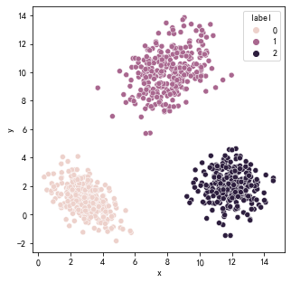

```python
import numpy as np
from numpy.random import multivariate_normal
import matplotlib.pyplot as plt
def make_data(len,mu,sigma): #alpha:隐变量权值（K）;mu多元高斯分布均值（n*K）;sigma多元高斯分布协方差矩阵（K*k）,len表示生成点数量
    data = pd.DataFrame()
    K = mu.shape[0]
    for k in range(K):
        x_k = multivariate_normal(mean = mu[k], cov = sigma[k], size=(len), check_valid="raise")
        points = pd.DataFrame(x_k,columns =["x","y"])
        points["label"] = k
        data = data.append(points)
        result = np.array(data.iloc[:,0:2])
    return result,data
mu = np.array([[3,1],[8,10],[12,2]])
sigma = np.array([[[1,-0.5],[-0.5,1]],[[2,0.8],[0.8,2]],[[1,0],[0,1]]])
result,data = make_data(300,mu,sigma) #生成300个数据点
plt.figure(figsize=(5,5))
sns.scatterplot(x="x",y ="y",data = data,hue = "label")
```

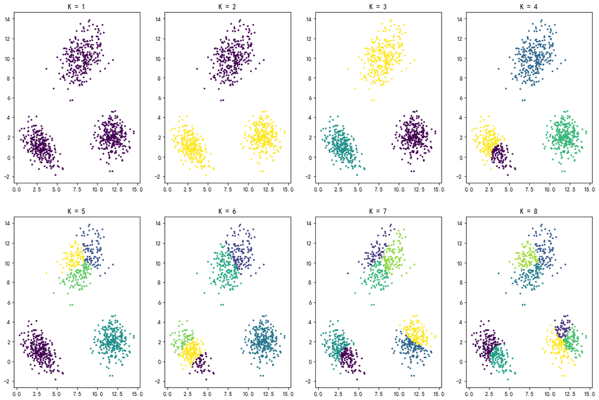

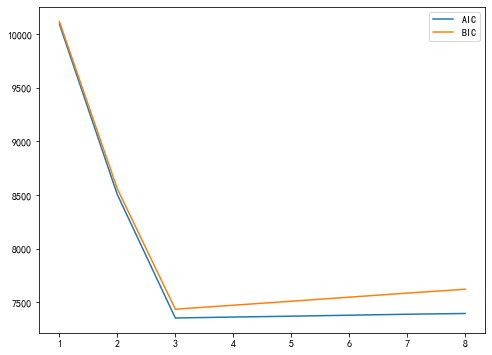

```python
from sklearn.mixture import GaussianMixture as GMM
AIC_list = []
BIC_list = []
plt.figure(figsize=(18,12))
for K in range(1, 9):
    gmm = GMM(n_components=K).fit(result)
    labels = gmm.predict(result)
    AIC_list.append(gmm.aic(result))
    BIC_list.append(gmm.bic(result))
    plt.subplot(2, 4, K)
    plt.scatter(result[:, 0], result[:, 1], c=labels, s=4)
    plt.title("K = {}".format(K))
    plt.savefig("Gaussian_result.png",dpi=300)
plt.figure(figsize=(8,6))
plt.plot(range(1,9),AIC_list,label = "AIC")
plt.plot(range(1,9),BIC_list,label = "BIC")
plt.legend()
plt.savefig("AIC-BIC.png",dpi=100)
```